# FordGo Bike system

## by Ishita Kundaliya

## Investigation Overview

> In this investigation of Ford Gobike system data , i wanted to look at the characteristics each variable and impact of different attributes like user type, day, month and ride duration on the gobike system

## Dataset Overview

> Ford GoBike is the Bay Area's bike share system. Bay Area Bike Share was introduced in 2013 as a pilot program for the region, with 700 bikes and 70 stations across San Francisco and San Jose. Once expansion is complete, Ford GoBike will grow to 7,000 bikes across San Francisco, the East Bay and San Jose.

> Ford GoBike, like other bike share systems, consists of a fleet of specially designed, sturdy and durable bikes that are locked into a network of docking stations throughout the city. The bikes can be unlocked from one station and returned to any other station in the system, making them ideal for one-way trips. People use bike share to commute to work or school, run errands, get to appointments or social engagements and more. It's a fun, convenient and affordable way to get around.

> The bikes are available for use 24 hours/day, 7 days/week, 365 days/year and riders have access to all bikes in the network when they become a member or purchase a pass.

> See the data [here](https://www.fordgobike.com/system-data)

### 1.month wise usage

the bikes are used most in the month of October followed by July and June

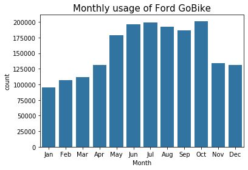

```python
bc=sb.color_palette()[0]
sb.countplot(data=ford_df,x='Month-st',color=bc)
plt.xlabel('Month')
plt.title('Monthly usage of Ford GoBike',fontsize = 15);
```

### 2.Different type of users

By merely looking at the above visualization we can say that more number of subscribers are using Ford Gobike system. About 85% of the users are subscribers

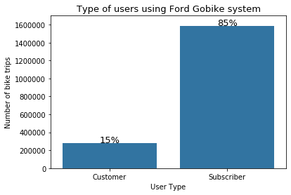

```python
uc = ford_df.user_type.value_counts()
uo = uc.index

for i in range(uc.shape[0]):
    count = uc[i]
    percent = '{:0.0f}%'.format(100*count/df.shape[0])
    plt.text(i,count+10000,percent,ha='center',color='black',fontsize=13)
sb.countplot(data=ford_df,x='user_type',color=bc)
plt.ylim(0,17e5)
plt.xlabel('User Type')
plt.ylabel('Number of bike trips');
plt.title('Type of users using Ford Gobike system',fontsize = 13);
```

### 3.percentage of users who opted for the bike share for all program

We can see that of all the users only 8.7% of them are a part of the bike share for all program

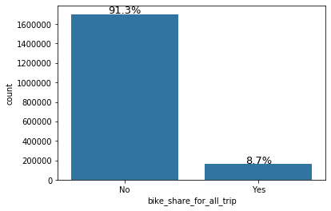

```python
uc = ford_df.bike_share_for_all_trip.value_counts()
uo = uc.index

for i in range(uc.shape[0]):
    count = uc[i]
    percent = '{:0.1f}%'.format(100*count/df.shape[0])
    plt.text(i,count+10000,percent,ha='center',color='black',fontsize=13)
sb.countplot(data=ford_df,x='bike_share_for_all_trip',color=bc)
```

### 4.Trip Duration

The average trip rate is just under 850 and 75% of the trips duration fall under 872 secs. From the visualisation we observe that popular duration is in the range of 300-850/1200 seconds (5-20 mins), which means that the riders are generally taking rides or shorter periods of time.

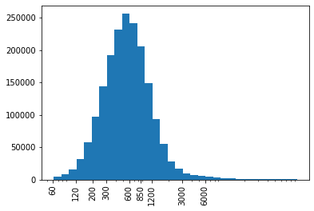

```python
bin_edges = 10**np.arange(np.log10(ford_df['duration_sec'].min()),np.log10(ford_df['duration_sec'].max()) + 0.1 , 0.1)
ticks = [60,120,200,300,600,850,1200,3000,6000]
labels = ['{}'.format(v) for v in ticks]
plt.hist(data=ford_df,x = 'duration_sec',bins = bin_edges, color=bc)
plt.xscale('log')
plt.xticks(ticks,labels,rotation=90);
```

### 5. Hourly usage

Ford Gobike system is mostly during 7-9:00 am in the morning and 4-6:00 pm in the evening with the peaks being 8:00 am and 5:00pm. this is bimodal since we will notice a dip in the middle.

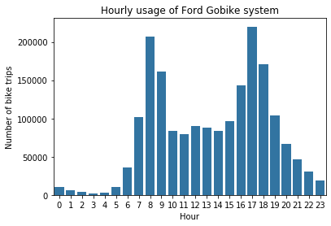

```python
sb.countplot(data = ford_df, x='start_hr',color = bc);
plt.ylabel('Number of bike trips')
plt.xlabel('Hour')
plt.title('Hourly usage of Ford Gobike system');
```

### 6.week day usage

We will see that the bikes are used almost all the days except on Saturdays and Sundays.The number of bike trips on Saturday and Sundays reduce by a very large number

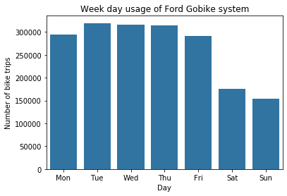

```python
sb.countplot(data = ford_df, x='start_day',color = bc,order =['Mon','Tue','Wed','Thu','Fri','Sat','Sun']);
plt.ylabel('Number of bike trips')
plt.xlabel('Day')
plt.title('Week day usage of Ford Gobike system');
```

### 1.Day of the week vs user type

Customers have a less usage of the bike share system with a small increase on the weekends. Subscribers have a high usage on weekdays, with a decline on the weekend. By the above graph we may think that subscribers are those who use bikes for daily work and customers are those who may be tourists or people who go out on weekends for movies or other such recreational purpose

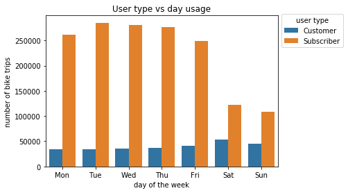

```python
sb.countplot(data=ford_df,x='start_day',hue ='user_type',order=['Mon','Tue','Wed','Thu','Fri','Sat','Sun'])
plt.xlabel('day of the week')
plt.ylabel('number of bike trips')
plt.title('User type vs day usage');
plt.legend(title = 'user type',loc = 6, bbox_to_anchor = (1.0, 0.9));
```

### 2.User type vs monthly usage

In January and February(winter) the bike sharing is the least whereas October has the highest number of bikes trips among subscribers.  
customers:demand is high during summer, reaching its peak in July. Customers are most probably tourists or occasional riders  
subscribers:the highest demand is from May till October. Subscribers are most likely riders using the bikes for their daily commute

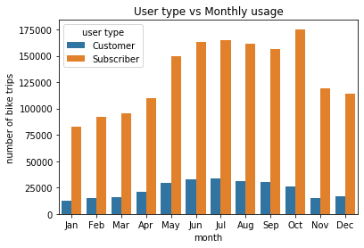

```python
sb.countplot(data=ford_df,x='Month-st',hue ='user_type')
plt.xlabel('month')
plt.ylabel('number of bike trips')
plt.title('User type vs Monthly usage');
plt.legend(title = 'user type')
```

### 3.User type vs bike_share_for_all_trip

We will find that none of the customers have taken up the bike share for all trip program

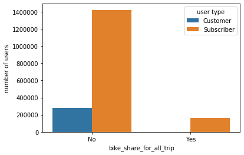

```python
sb.countplot(data=ford_df,x='bike_share_for_all_trip',hue ='user_type')
plt.ylabel('number of users')
plt.legend(title = 'user type')
```

### 4.Month vs trip duration

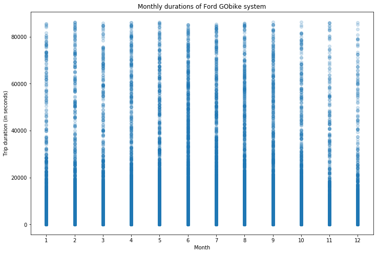

```python
plt.figure(figsize=[12,8])
plt.scatter(data=ford_df , x='start_month', y='duration_sec',alpha=0.2)
plt.xlabel('Month')
plt.ylabel('Trip duration (in seconds)')
plt.title('Monthly durations of Ford GObike system')
plt.xticks([1,2,3,4,5,6,7,8,9,10,11,12],[1,2,3,4,5,6,7,8,9,10,11,12]);
```

### 5.user type vs trip duration

Customer typically have trip durations that are longer (300 to 1800 seconds ) than for subscribers (300 to 900 seconds) according to above plot.

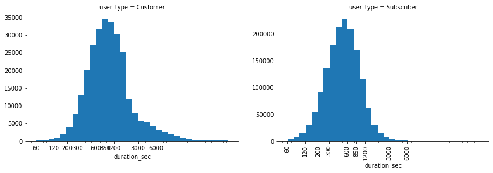

```python
bins = 10**np.arange(np.log10(ford_df['duration_sec'].min()),np.log10(ford_df['duration_sec'].max()) + 0.1 , 0.1)
ticks = [60,120,200,300,600,850,1200,3000,6000]
labels = ['{}'.format(v) for v in ticks]
g = sns.FacetGrid(data=ford_df , col = 'user_type',height=4,aspect =1.5,sharey=False)
g=g.map(plt.hist,'duration_sec', bins = bins)
plt.xscale('log')
plt.xticks(ticks,labels,rotation=90);
```

### 1.Trip duration in days of week between the different users

It is observed that subscribers ride or a shorter amout of time.However, this ride time increases for both subscribers and customers on the weekends

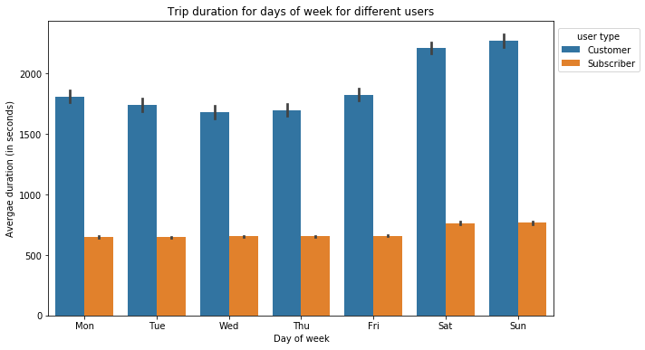

```python
plt.figure(figsize=[10,6])
sb.barplot(data=ford_df,x='start_day',y='duration_sec',hue='user_type',order=['Mon','Tue','Wed','Thu','Fri','Sat','Sun'])
plt.xlabel('Day of week')
plt.ylabel('Avergae duration (in seconds)')
plt.title('Trip duration for days of week for different users')
plt.legend(title = 'user type',loc = 6, bbox_to_anchor = (1.0, 0.9));
```

### 2.How is trip duration per month related to user type

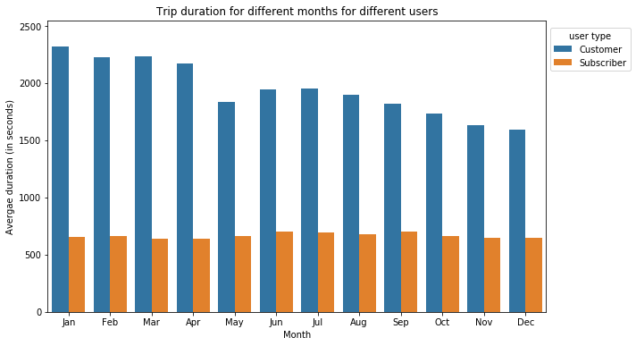

```python
plt.figure(figsize=[10,6])
sb.barplot(data=ford_df,x='Month-st',y='duration_sec',hue='user_type',errwidth=0)
plt.xlabel('Month')
plt.title('Trip duration for different months for different users')
plt.ylabel('Avergae duration (in seconds)')
plt.legend(title = 'user type',loc = 6, bbox_to_anchor = (1.0, 0.9));
```

### 3.Trip duration for each weekday in each month for both the user types

For subscribers: The average duration of ride(sec) in every month is always highest on weekends and there is no significant difference in avergae duration of ride change on weekdays.

For customers:mostly the average duration of ride in every month is greater on weekends.

From above plots it is evident that, for any type of user the average duration of ride is highest on weekends in every month

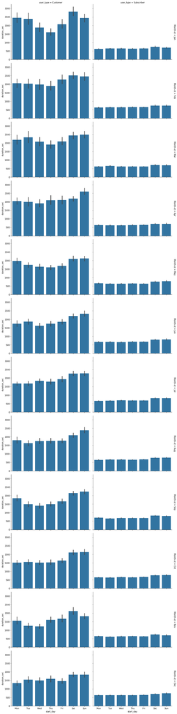

```python
a = sb.FacetGrid(data = ford_df, row ='Month-st' , col = 'user_type',
                  margin_titles = True,height = 4,aspect = 1.5)
a = a.map(sb.barplot,'start_day','duration_sec',color=bc,order =  ['Mon','Tue','Wed','Thu','Fri','Sat','Sun'])
```

### Summary:

> The multivariate exploration of data strengthened some of the patterns discovered in the bivariate exploration and univariate exploration. The short period of usage for subscribers corresponds to their usage of bikes during rush hours(8-9am and 5-6pm) Monday to Friday, indicating the use is for work commute. The pattern of customer shows that they're taking advantage of the bike sharing system a lot over weekends for city tour or leisure purpose probably.